# Statistik och dataanalys I

F9: Regression med dummyvariabler och modellval

Valentin Zulj

## Vad har vi gjort hittills?

- Hittills har vi pratat om
  - **Enkel** och **multipel** linjär regression
  - Hur vi bestämmer koefficienter och gör prediktioner
  - Hur vi utvärderar modellantaganden och modeller
  - Hur vi transformerar för att uppnå linjäritet

## Vad vi ska göra nu?

- I denna föreläsning ska vi prata om
  - Gruppvisa analyser med dummyvariabler i regressionsmodeller
  - Hur vi kan välja mellan olika regressionsmodeller
  - Hur vi kan använda träningsdata och testdata i punkten ovan
  - Korsvalidering

# Regressionsanalys med dummyvariabler

## Dummyvariabler (dummy variables / indicator variables)

- Vi har hittills bara använt **numeriska förklaringsvariabler** i våra regressionsmodeller
- Det är dock också möjligt att använda **kategoriska förklaringsvariabler** för att göra gruppvisa regressionsanalyser
- Vi skulle t.ex. kunna dela upp analysen av bränsleförbrukning efter bilens växellåda (manuell/automatisk)

## Dummyvariabler (dummy variables / indicator variables)

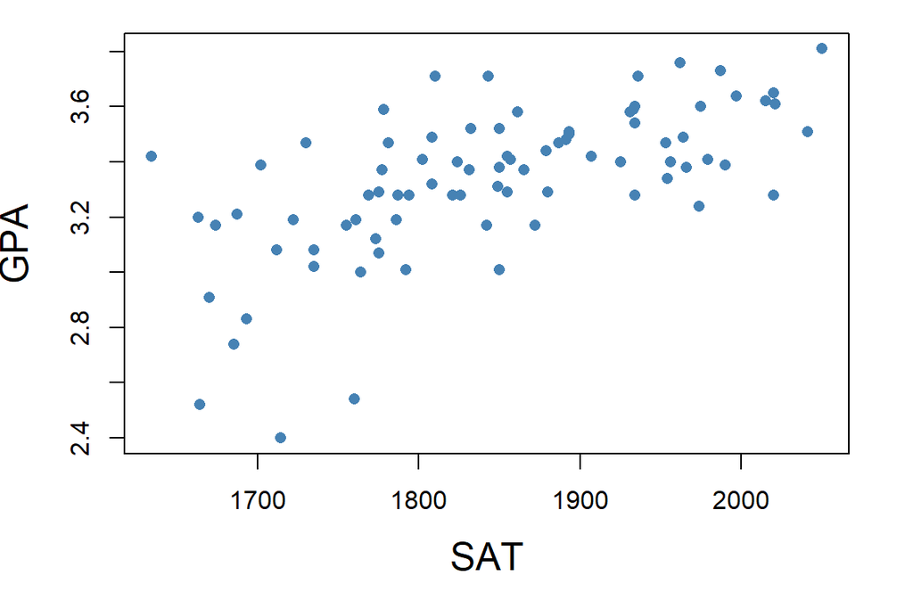

- Antag att vi vill prediktera amerikanska studenters snittbetyg (GPA) med *SAT score* som förklaringsvariabel (SAT är ett “amerikanskt högskoleprov”)
- Diagrammet tyder på ett positivt samband mellan dessa numeriska variabler

## Motivering av regression med dummyvariabler

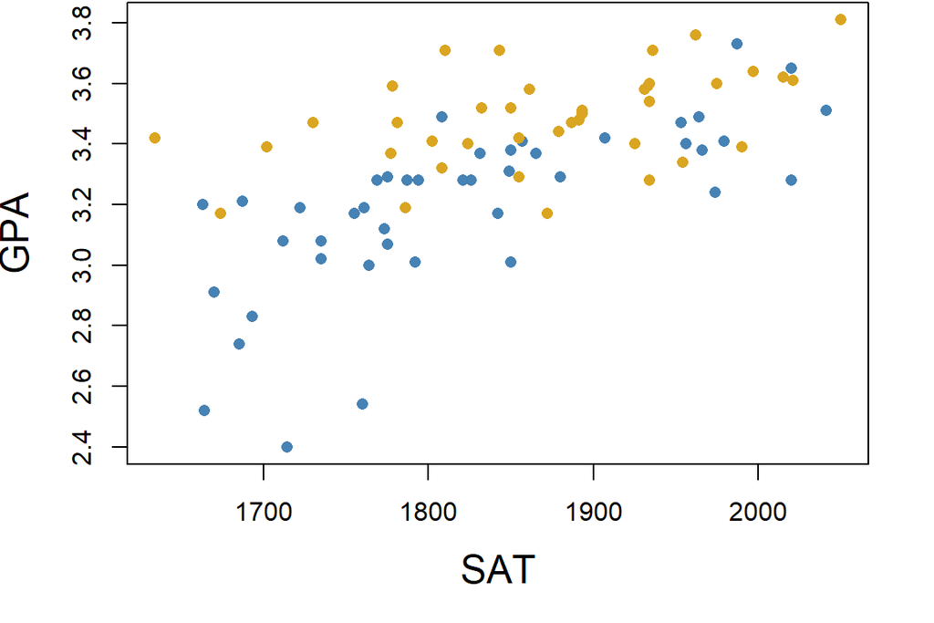

- Antag att vi också har en variabel **attendance**, som har värdet *yes* om studenten deltagit på minst 75% av föreläsningarna och *no* i annat fall
- I denna figur är punkter som representerar studenter med hög närvaro **gula**
- Studenter med hög närvaro tycks generellt ha högre snittbetyg, givet sin SAT-poäng – vi vill gärna använda detta i vår regressionsmodell!

## Skapa en dummyvariabel

- Vi har konstaterat att variabeln *attendance* är kategorisk
- Vi kan använda den i en regressionsmodell om vi kodar om den så att den blir en numerisk **dummyvariabel**
- En dummyvariabel har antingen värdet 1 eller värdet 0, beroende på vilken av de två kategorierna
  - Vi ger dummyvariabeln värdet **1** om $\text{attendance}=\text{"yes"}$
  - Vi ger dummyvariabeln har värdet **0** om $\text{attendance}=\text{"no"}$
- **Vi skulle lika gärna kunna göra tvärtom**, det spelar ingen roll vilken kategori som blir 0 och vilken som blir 1

## Skapa en dummyvariabel

```r
GPA$high_attendance_dummy <-
  ifelse(test = (GPA$high_attendance == "yes"), yes = 1, no = 0)
GPA[c(1, 16), ]
```

```
    GPA  SAT high_attendance high_attendance_dummy
1  2.40 1714              no                     0
16 3.17 1872             yes                     1
```

- Vi skapar en dummyvariabel av vår kategoriska variabel med funktionen `ifelse()`, som går igenom varje värde av variabeln *high_attendance*
  - `test = (GPA$high_attendance == "yes")` betyder att funktionen för varje observation testar påståendet att *high_attendance* är “yes”
  - Om påståendet är sant förvandlas motsvarande observation till `1`, och om påståendet är falskt blir observationen `0`
  - Resultatet sparas i en ny variabel med namnet *high_attendance_dummy*

## Regression med en dummyvariabel

- Nu när vi har skapat en dummyvariabel använder vi den på samma sätt som en vanlig numerisk variabel
- Vår modell för att prediktera snittbetyg blir

$$\widehat{\text{GPA}} = b_0 + b_1 \cdot \text{SAT} + b_2 \cdot \text{HighAttendance}$$

- Vi använder `lm()`-funktionen för att hitta koefficienternas värden

```r
lm(GPA ~ SAT + high_attendance_dummy, data=GPA)$coefficients
```

```
          (Intercept)                   SAT
          0.643850459           0.001399802
high_attendance_dummy
          0.222644088
```

## Tolkning av regression med dummyvariabel

- Nu när vi har våra koefficienter kan vi skriva modellen som

$$\widehat{\text{GPA}} = 0.644 + 0.0014 \cdot \text{SAT} + 0.223 \cdot \text{HighAttendance}$$

- **Tolkning:** Modellen uppskattar att en student med hög närvaro har ett snittbetyg som är 0.223 högre än en student som *inte* har hög närvaro, **givet en viss SAT-poäng**
- **Exempel**
  - Vi har två studenter med **exakt samma** SAT-poäng, men där en av dem har hög närvaro och den andra inte har det
  - Modellen uppskattar då att studenten med hög närvaro kommer ha ett snittbetyg som är 0.223 poäng högre

## Tolkning av regression med dummyvariabel

- Koefficienten som är kopplad till dummyvariabeln visar hur kategorin som kodats till `1` förhåller sig till kategorin som kodats till `0`
- När vi kodade *hög närvaro* som 1 och *ej hög närvaro* som 0 fick vi
  $$\widehat{\text{GPA}} = 0.644 + 0.0014 \cdot \text{SAT} + 0.223 \cdot \text{HighAttendance}$$
- Kategori `1` har **högre** snittpoäng än kategori `0`
- Om vi i stället hade kodat *ej hög närvaro* som 1 och *hög närvaro* som 0, hade vi fått motsatsen

$$\widehat{\text{GPA}} = 0.867 + 0.0014 \cdot \text{SAT} - 0.223 \cdot \text{NotHighAttendance}$$

## Tolkning av regression med dummyvariabel

$$\widehat{\text{GPA}} = 0.867 + 0.0014 \cdot \text{SAT} - 0.223 \cdot \text{NotHighAttendance}$$

- Denna modell uppskattar att en student **som inte har hög närvaro** har ett snittbetyg som är 0.223 **lägre** än en student som *har* hög närvaro, **givet en viss SAT-poäng**
- Båda modellerna kommer ge samma uppskattade snittbetyg för en given student
- Detta beror på att **interceptet** förändras när vi kodar om dummyvariabeln
- I denna modellen blir termen $b_2 \cdot \text{NotHighAttendance}$ *0.223* lägre än i den första modellen för varje student, men interceptet är samtidigt 0.223 *högre*

## Regression med dummyvariabel

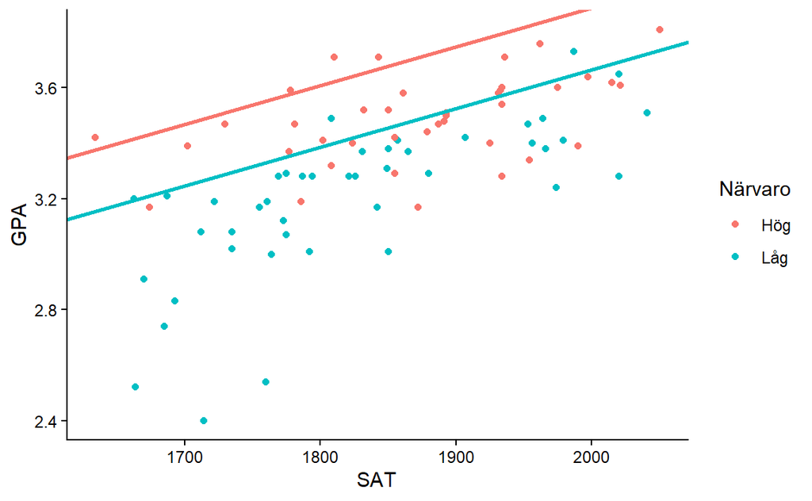

# Val av regressionsmodell

## Modellval

- Hittills har vi framför allt undersökt
  - Hur vi **tolkar** en regressionsmodell
  - Hur vi **transformerar** variabler för hitta samband som är någorlunda linjära
  - Hur vi använder måttet $R^2$ som säger oss något om hur väl modellen förklarar responsvariabelns värden
- Nu kommer vi in på frågan om **modellval**, som inbegriper frågor om t.ex.
  - Vilka variabler som är relevanta att använda i vår modell
  - Om någon/några variabler bör transformeras innan de tas med i modellen

## Val av variabler

- En naturlig fråga att ställa är: Varför välja ut vissa variabler och välja bort andra? Kan vi inte bara inkludera **alla** tillgängliga variabler?
- När vi tar med alla variabler gör vi $R^2$ så stort som möjligt, men vi vet att $R^2$ alltid ökar när vi lägger till fler variabler (och inte alltid är att lita på)
- I allmänhet gäller att modellen blir mer **flexibel** ju fler variabler vi lägger till, men detta kan vara både en styrka och en svaghet
- Låt oss titta närmare på vad vi menar med att en modell är flexibel, och varför vi vill undvika att en modell *för* flexibel!

## Flexibilitet

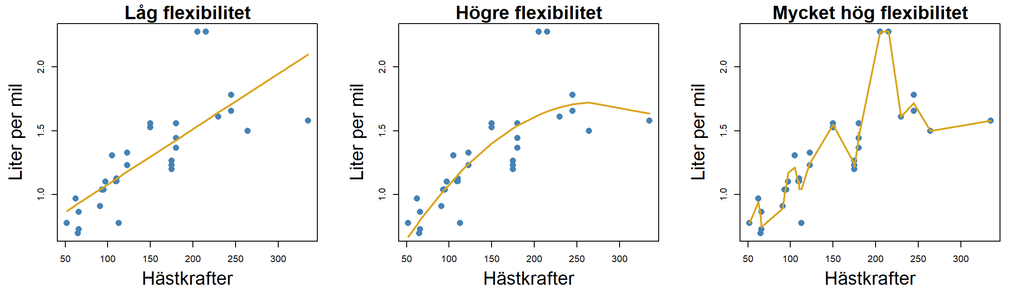

- Här ser vi **3 regressionsmodeller** som estimerar en bils bränsleförbrukning med förklaringsvariabeln hästkrafter
- Vi bryr oss i det här sammanhanget inte om hur modellerna är konstruerade, utan vi konstaterar bara att de har olika stor flexibilitet
- En mer flexibel en modell följer **responsvariabelns värden** närmare

## Flexibilitet

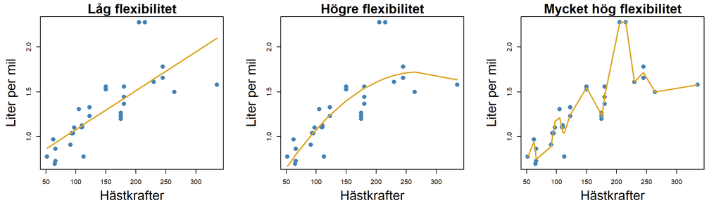

- Den minst flexibla modellen är en **rät linje**
- Den något mer flexibla modellen i mitten **följer det övergripande mönstret**
- Den mest flexibla modellen **anpassar sig tydligt efter de enskilda datapunkterna**

## Flexibilitet

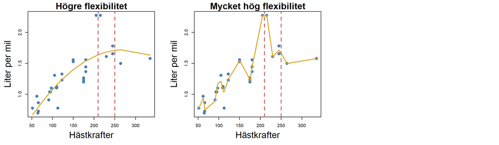

- Kom ihåg att en bra modell ska ge **rimliga estimat** för **nya observationer**
- Om vi har två nya bilar, en med 210 hästkrafter och en med 250 hästkrafter, vilken av modellerna ger de rimligaste prediktionerna?
- Det verkar orimligt att bilar med 210 hästkrafter **generellt** skulle ha betydligt större bränsleförbrukning än bilar med 250 hästkrafter

## Generaliserbarhet

- Vi säger att en modell är **generaliserbar** om den hade sett ungefär likadan ut om vi anpassade den till andra (men liknande) data
- Vi kan tänka att vi helt plötsligt får data på 32 andra bilmodeller, och skattar de båda modellerna igen
- Vad skulle hända då?

## Generaliserbarhet

- Den vänstra modellen skulle förmodligen bli ungefär likadan, då den fångar upp ett övergripande mönster (mer generaliserbar)
- Den högra modellen skulle troligtvis se helt annorlunda ut, då den är väldigt exakt anpassad till de enskilda punkterna (mindre generaliserbar)

## Generaliserbarhet och överanpassning

- En flexibel modell med dålig generaliserbarhet sägs vara **överanpassad** (overfitted)
- Den högra modellen är alltså en överanpassad modell, den är för anpassad till de enskilda punkterna, och bortser så från det övergripande mönstret

## Generaliserbarhet och underanpassning

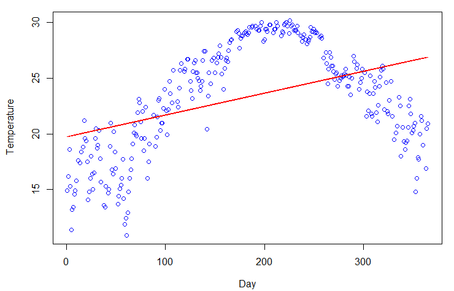

- En modell sägs vara **underanpassad** (underfitted) om den
  - **Inte** är flexibel, och
  - **Inte** fångar det övergripande mönstret i data
- Den röda linjen i bilden beskriver en underpassad modell, som inte fångar det uppenbara bågformade mönstret i datamaterialet

## Trade-off mellan över- och underanpassning

- Vi har sett att både över- och underanpassade modeller är problematiska, och målet när vi väljer modell är att hitta en bra medelväg mellan de båda
- Vi vill ta fram en modell som är
  - Tillräckligt flexibel för att **fånga det övergripande mönstret**
  - Tillräckligt restriktiv för att**inte fånga alla slumpvisa variationer**
- Kort sagt vill vi modellera “signalen” i data, och samtidigt ignorera “bruset”
- Hur gör vi det?

## Modellval med hjälp av $R_{\text{adj}}^2$

- Vi har tidigare nämnt $R^2$, och att $R^2$ alltid växer när vi lägger till variabler
- $R^2 = 1$ när modellen träffar alla punkter, alltså när den är helt överanpassad
- Om vårt mål är att maximera $R^2$ kommer vi så att överanpassa modellen
- Vi har också talat om **justerat $R^2$**
  $$R_{\text{adj}}^2 = 1 - \cfrac{(1 - R^2)(n-1)}{n-k-1}$$
- Vi vet att $R_{\text{adj}}^2$ kan bli mindre när antalet variabler ökar, vilket betyder att $R_{\text{adj}}^2$ tar så hänsyn till generaliserbarhet i viss mån
- Det då är rimligt att försöka maximera $R_{\text{adj}}^2$ när vi söker den bästa modellen
- Det finns mer dock sofistikerade sätt att mäta hur bra en modell är, som ofta ger bättre resultat i praktiken

## Träningsdata och testdata

- Vi har sagt att en generaliserbar modell är en modell som fungerar även för **nya data** (data som vi inte använde när vi anpassade modellen)
- Ett bra sätt att bedöma om modellen är generaliserbar är att helt enkelt **testa** hur bra prediktionerna blir på nya data
- För att göra detta kan vi dela vårt dataset i två delar
  - Fen ena delen kallas **träningsdata** (training data), och används för att anpassa modellen (hitta $b_0$, $b_1$, osv)
  - Den andra delen kallas **testdata**, och används för att utvärdera modellen

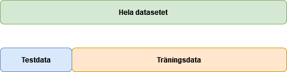

## Träningsdata och testdata

- Nedan ser vi en model som inte är flexibel, och en modell som är det
- Den flexibla modellen passar träningsdata bra, men nya data väldigt dåligt

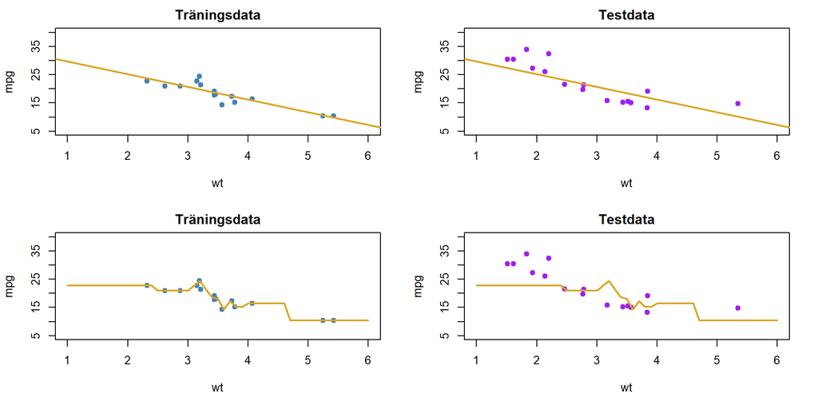

## Träningsdata och testdata

- Vi kan t.ex. använda 70% av observationerna som träningsdata, och de övriga 30% av observationerna som testdata
- Om observationerna ligger i någon särskild ordning bör vi **sortera dem slumpmässigt** innan vi gör uppdelningen
- Vi vill att både tränings- och testdata ska vara **representativa** för hela datamaterialet (t.ex. inte bara ha hushåll från en stadsdel i testdata)

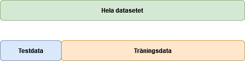

## Träningsdata och testdata

- För att utvärdera en modell på testdata följer vi stegen nedan
  1. Dela upp observationerna i träningsdata och testdata
  2. Anpassa regressionsmodellen med hjälp av träningsdata
  3. Utvärdera modellen med hjälp av testdata
- Till steg 3 behöver vi ett mått som utvärderar hur väl en modell passar våra testdata
- Det många alternativ, men vi använder **RMSE (Root Mean Squared Error)**
- I allmänhet gäller att ju **mindre RMSE**, desto **bättre modell**

## Modellval - träningsdata och testdata

- Vi räknar ut RMSE på testdata med formeln
  $$\text{RMSE}_\text{test} = \sqrt{\cfrac{\sum_{i=1}^{n_\text{test}} (y_i - \hat{y}_i)^2}{n_\text{test}}},$$
- Vi summerar över alla observationer i testdata, och $n_\text{test}$ är så antalet observationer i testdata

## Modellval - träningsdata och testdata

- Det är ofta lättast (rent räknemässigt) att beräkna $\text{RMSE}_\text{test}$ i flera steg
  1. Beräkna $\text{SSE}_\text{test} = \sum_{i=1}^{n_\text{test}} (y_i - \hat{y}_i)^2$
  2. Beräkna $\text{MSE}_\text{test} = \cfrac{\text{SSE}_\text{test}}{n_\text{test}}$
  3. Beräkna $\text{RMSE}_\text{test} = \sqrt{\text{MSE}_\text{test}}$
- Vi använder ofta $\text{SSE}_\text{test}$ till flera olika saker, så det är bra att beräkna det separat för att slippa repetera

## Träningsdata och testdata

- Vi tittar nu på ett exempel, där vi
  1. Delar upp ett dataset i träningsdata och testdata
  2. Anpassar modellen med hjälp av vår träningsdata
  3. Utvärderar modellen genom att räkna ut RMSE för vår testdata

## Exempel

- Vi använder ett dataset med variablerna $y$, $x_1$, $x_2$ och $x_3$ – där $y$ är responsvariabel och övriga variabler är förklaringsvariabler
- Vilka förklaringsvariabler vi inkluderar är upp till oss själva, och målet är att hitta en modell som ger bra prediktioner i vår testdata
- Vi har totalt 100 observationer, och de första ser ut såhär:

```
         y       x1       x2         x3
1 31.41966 16.88882 5.599934 -0.7104066
2 32.39954 25.40119 3.996941  0.2568837
3 26.59989 18.95261 4.931678 -0.2466919
4 39.44798 27.01130 7.726843 -0.3475426
```

## Steg 1: Dela upp data

- Vi börjar med att dela in våra data i en träningsdel och ett testdel
- Det gör vi genom att först lägga observationerna i slumpvis ordning
- Därefter låter vi de första 70 observationerna utgöra träningsdata
- Till sist får de återstående 30 observationerna bli testdata

```r
library(dplyr)
data_randomorder <- data %>% slice_sample(prop=1)
datatrain <- data_randomorder %>% slice(1:70)
datatest <- data_randomorder %>% slice(71:100)
```

## Steg 2: Träna modellen $y = b_0 + b_1 x_1 + b_2 x_2$

```r
model1 <- lm(y ~ x1 + x2, data=datatrain) #Träna modellen
summary(model1) #Se sammanfattande resultat
```

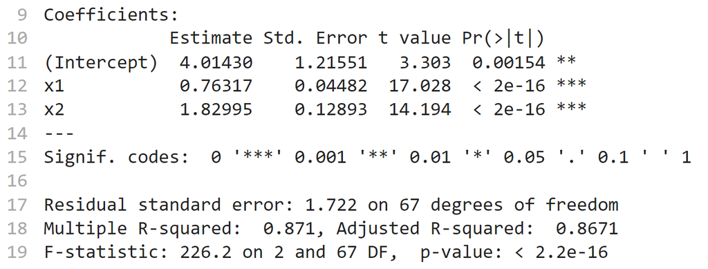

## Steg 3: Utvärdera på testdata

- Vi vill nu beräkna $\text{RMSE}_\text{test}$, och beräknar $\text{SSE}_\text{test}$, $\text{MSE}_\text{test}$ och $\text{RMSE}_\text{test}$ i tur och ordning

```r
rsquared1 <- summary(model1)$r.squared
y_hatt_test <- predict(model1, newdata=datatest)
y_test <- datatest$y
SSE <- sum((y_test - y_hatt_test)^2)
n_test <- 30
MSE <- SSE / n_test
RMSE <- sqrt(MSE)
sprintf("R-squared=%.7f, SSE=%.7f", rsquared1, SSE)
```

```
[1] "R-squared=0.8709888, SSE=146.0526235"
```

```r
sprintf("MSE=%.7f, RMSE=%.7f", MSE, RMSE)
```

```
[1] "MSE=4.8684208, RMSE=2.2064498"
```

## Upprepa för modellen $y = b_0 + b_1 x_1 + b_2 x_2 + b_3 x_3$

```r
model2 <- lm(y ~ x1 + x2 + x3, data=datatrain)
rsquared2 <- summary(model2)$r.squared
y_hatt_test <- predict(model2, newdata=datatest)
y_test <- datatest$y
SSE2 <- sum((y_test - y_hatt_test)^2)
n_test <- 30
MSE2 <- SSE2 / n_test
RMSE2 <- sqrt(MSE2)
sprintf("R-squared=%.7f, SSE=%.7f", rsquared2, SSE2)
```

```
[1] "R-squared=0.8710176, SSE=146.5228725"
```

```r
sprintf("MSE=%.7f, RMSE=%.7f", MSE2, RMSE2)
```

```
[1] "MSE=4.8840958, RMSE=2.2099990"
```

## Jämförelse av modellerna

- Vi jämför modellerna i tabellen nedan, där vi har
  - Modell 1: $y = b_0 + b_1 x_1 + b_2 x_2$
  - Modell 2: $y = b_0 + b_1 x_1 + b_2 x_2 + b_3 x_3$

| Model | R.squared | SSE | MSE | RMSE |
| --- | --- | --- | --- | --- |
| Model 1 | 0.8709888 | 146.0526 | 4.868421 | 2.206450 |
| Model 2 | 0.8710176 | 146.5229 | 4.884096 | 2.209999 |

- Skillnaderna mellan modellerna är små, men det finns saker att notera
- Baserat på R-squared kunde man tro att modell 2 är bättre, då den förklarar en aning mer av variationen i vår träningsdata
- RMSE är samtidigt något **mindre** för modell 1, vilket betyder att den modellen är lite **bättre** på att göra prediktioner på vår testdata

## Träningsdata och testdata

- Att dela upp ett dataset i träningsdata och testdata ger oss en bättre bild av hur användbar en modell är
- Vi vet dock inte säkert om bilden blir helt rättvis, särskilt om det är ett dataset med få observationer
- Som exempel på detta använder vi våra bildata, och modellen $\widehat{\text{litermil}} = b_0 + b_1 \cdot \text{viktton}$
  - Först använder vi **de 12 sista** observationerna som testdata, och de 20 första som träningsdata
  - Sedan gör vi samma sak, men använder i stället **de 12 första** som testdata, och de 20 sista som träningsdata

## Träningsdata och testdata

- Vi kodar upp exemplet i R, och börjar med de 12 sista observationerna som testdata

```r
# De 12 sista observationerna används i vårt testset
carstrain <- mtcars %>% slice(1:20)
carstest <- mtcars %>% slice(21:32)
lmod1 <- lm(litermil ~ viktton, data=carstrain)
y_hatt <- predict(lmod1, newdata=carstest)
RMSE <- sqrt(mean((carstest$litermil - y_hatt)^2))
print(RMSE)
```

```
[1] 0.1984769
```

## Träningsdata och testdata

- Vi gör nu om analysen, fast med de 12 **första** observationerna som testdata

```r
# De 12 första observationerna används i vårt testset
carstrain <- mtcars %>% slice(13:32)
carstest <- mtcars %>% slice(1:12)
lmod1 <- lm(litermil ~ viktton, data=carstrain)
y_hatt <- predict(lmod1, newdata=carstest)
RMSE <- sqrt(mean((carstest$litermil - y_hatt)^2))
print(RMSE)
```

```
[1] 0.1790871
```

## Träningsdata och testdata

- Med de *sista* 12 observationerna som testdata fick vi $\text{RMSE}=0.198$
- Med de *första* 12 observationerna som testdata fick vi $\text{RMSE}=0.179$
- Vi ser så att $\text{RMSE}$ skiljer sig relativt mycket, beroende på hur vi delar upp våra data
- Ett sätt att komma runt detta problem är att använda något som kallas för **korsvalidering** (cross validation)

## Korsvalidering

- Korsvalidering är en metod som låter oss använda **alla** observationer **både** som träningsdata **och** som testdata
- När vi använder korsvalidering delar vi upp våra data i tränings- respektive testdelar flera gånger
- Efter varje uppdelningen får vi en ny uppsättning punkter som testdata
- Varje observation hamnar i testdata **en** gång, och i träningsdata i övriga uppdelningar

## Korsvalidering

- Varje uppdelning kallas för en fold
- Korsvalisering kallas ibland $K$-fold cross validation, där $K$ är antalet folds
- Korsvalidering med $K = 4$ betyder exempelvis att vi delar in vår data i tränings- och testdata på 4 olika sätt

## Korsvalidering

- För var och en av de 4 uppdelningarna räknar vi ut SSE på testdata
- Vi använder sedan summan av de 4 SSE-värdena för att beräkna RMSE

## Korsvalidering

- Antag att vi har ett dataset med 100 observationer och $K=4$
  - För $k=1$ gäller då att observation 1 till 25 utgör testdata
  - För $k=2$ gäller att observation 26 till 50 utgör testdata,
  - Och så vidare

## Korsvalidering

- Vårt mål är att räkna ut RMSE med hjälp av våra 4 folds
- Vi börjar med att räkna ut SSE för varje enskild fold, och summerar sedan våra fyra värden som
  $$\text{SSE}_\text{cv} = \text{SSE}_\text{test}^{(1)} + \text{SSE}_\text{test}^{(2)} + \text{SSE}_\text{test}^{(3)} + \text{SSE}_\text{test}^{(4)}$$
- När vi har tagit fram $\text{SSE}_\text{cv}$ kan vi beräkna
  $$\text{MSE}_\text{cv} = \frac{\text{SSE}_\text{cv}}{n} \; \text{ och } \; \text{RMSE}_\text{cv} = \sqrt{\text{MSE}_\text{cv}}$$
- Notera: $\text{cv}$ i subscript står för cross validation

## Korsvalidering

- **Procedur för enkel uppdelning i tränings- och testdata:**
  1. Räkna ut $\text{SSE}_\text{test}$
  2. Räkna ut $\text{MSE}_\text{test} = \text{SSE}_\text{test} / n_{\text{test}}$
  3. Räkna ut $\text{RMSE}_\text{test} = \sqrt{\text{MSE}_\text{test}}$
- **Procedur för korsvalidering:**
1. Räkna ut $\text{SSE}_\text{test}^{(1)}, \text{SSE}_\text{test}^{(2)},...,\text{SSE}_\text{test}^{(K)}$, och därefter
   $$\text{SSE}_\text{CV} = \text{SSE}_\text{test}^{(1)}+\text{SSE}_\text{test}^{(2)}+...+\text{SSE}_\text{test}^{(K)}$$
2. Räkna ut $\text{MSE}_\text{CV} = \text{SSE}_\text{CV} / n$
3. Räkna ut $\text{RMSE}_\text{CV} = \sqrt{\text{MSE}_\text{CV}}$

## Exempel på korsvalidering med $K=2$

- Vi arbetar nu igenom ett exempel på korsvalidering, med hjälp av R
- Vi använder våra bildata med 32 observationer, och utvärderar den enkla modellen med vikt som förklaringsvariabel
- Vi sätter $K=2$, det vill säga vi använder 2 folds
- När vi räknar ut $\text{SSE}_\text{test}^{(1)}$ låter vi de 16 **första** observationerna vara testdata, och använder övriga observationer träningsdata
- När vi räknar ut $\text{SSE}_\text{test}^{(2)}$ låter vi de 16 **sista** observationerna vara testdata, och använder de övriga observationerna som träningsdata

## Exempel på korsvalidering med $K=2$

- Med koden nedan kan vi beräkna $\text{SSE}_\text{test}^{(1)}$ och $\text{SSE}_\text{test}^{(2)}$

```r
# Räkna ut SSE(1)
carstest <- mtcars %>% slice(1:16)
carstrain <- mtcars %>% slice(17:32)
lmod1 <- lm(litermil ~ viktton, data=carstrain)
y_hatt1 <- predict(lmod1, newdata=carstest)
y1 <- carstest$litermil
SSE1 <- sum((y1 - y_hatt1)^2)

# Räkna ut SSE(2)
carstest <- mtcars %>% slice(17:32)
carstrain <- mtcars %>% slice(1:16)
lmod2 <- lm(litermil ~ viktton, data=carstrain)
y_hatt2 <- predict(lmod2, newdata=carstest)
y2 <- carstest$litermil
SSE2 <- sum((y2 - y_hatt2)^2)
```

## Exempel på korsvalidering med $K=2$

Vi skriver ut värdena på $\text{SSE}_\text{test}^{(1)}$ och $\text{SSE}_\text{test}^{(2)}$

```r
#Skriv ut värdet på SSE(1) och SSE(2)
sprintf("SSE1 = %.4f, SSE2 = %.4f", SSE1, SSE2)
```

```
[1] "SSE1 = 0.5331, SSE2 = 1.0270"
```

## Exempel på korsvalidering med $K=2$

- Bilderna visar våra data och de två regressionsmodellerna (en för varje fold)
- Om vi kvadrerar de röda linjerna i bilderna till höger och summerar kvadraterna får vi $\text{SSE}_\text{test}^{(1)}$ (övre) och $\text{SSE}_\text{test}^{(2)}$ (undre)

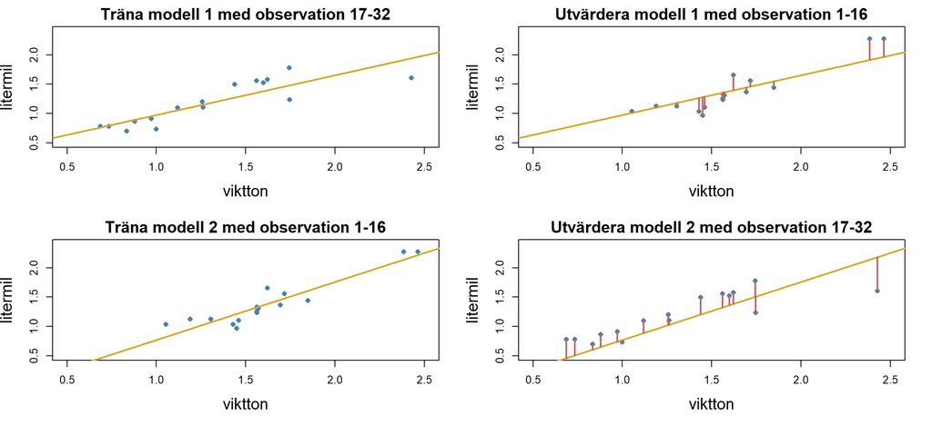

## Exempel på korsvalidering med $K=2$

- Vi har räknat ut
  - $\text{SSE}_\text{test}^{(1)} = 0.5331$
  - $\text{SSE}_\text{test}^{(2)} = 1.0270$
- Nu kan vi räkna ut

$$\text{SSE}_\text{CV} = \text{SSE}_\text{test}^{(1)} + \text{SSE}_\text{test}^{(2)} = 0.5331 + 1.0270 = 1.5601$$

$$\text{MSE}_\text{CV} = \cfrac{\text{SSE}_\text{CV}}{n} = \cfrac{1.5601}{32} = 0.04875312$$
$$\text{RMSE}_\text{CV} = \sqrt{\text{MSE}_\text{CV}} = \sqrt{0.04875312}=0.2208011$$

## Exempel på korsvalidering med $K=2$

- Normalt gör vi våra uträkningar i programkoden

```r
n <- 32
SSE_cv <- SSE1 + SSE2
MSE_cv <- SSE_cv / n
RMSE_cv <- sqrt(MSE_cv)
sprintf("RMSE är %.5f", RMSE_cv)
```

```
[1] "RMSE är 0.22080"
```

## Exempel på korsvalidering med $K=2$

- Nu har vi räknat ut $\text{RMSE}_\text{CV}$ för **en** regressionsmodell
- För att jämföra **flera** modeller måste vi räkna ut $\text{RMSE}_\text{CV}$ för **varje** modell
- När vi har gjort detta väljer vi den modell om har **lägst** $\text{RMSE}_\text{CV}$
- När vi, till slut, har valt en modell att använda, så anpassar vi den till **alla data**
- Eftersom den valda modellen är avsedd att användas, vill vi använda så mycket information som möjligt när vi anpassar den

## Credits

Dessa slides skapades av Karl Sigfrid för kursen Statistik och Dataanalys I och har uppdaterats av Oskar Gustafsson och Valentin Zulj